# Exploració de dades

```python
# import data manipulation library
import pandas as pd
import numpy as np

# import visualization library
import matplotlib.pyplot as plt

# dataset
delay = pd.read_csv('AirDelay/DelayedFlights.csv')
```

```python
pd.set_option('display.max_columns', None) # None = Nº columnas a mostrar
delay.head(3)
```

|  | Unnamed: 0 | Year | Month | DayofMonth | DayOfWeek | DepTime | CRSDepTime | ArrTime | CRSArrTime | UniqueCarrier | FlightNum | TailNum | ActualElapsedTime | CRSElapsedTime | AirTime | ArrDelay | DepDelay | Origin | Dest | Distance | TaxiIn | TaxiOut | Cancelled | CancellationCode | Diverted | CarrierDelay | WeatherDelay | NASDelay | SecurityDelay | … |
| --- | --- | --- | --- | --- | --- | --- | --- | --- | --- | --- | --- | --- | --- | --- | --- | --- | --- | --- | --- | --- | --- | --- | --- | --- | --- | --- | --- | --- | --- | --- |
| 0 | 0 | 2008 | 1 | 3 | 4 | 2003.0 | 1955 | 2211.0 | 2225 | WN | 335 | N712SW | 128.0 | 150.0 | 116.0 | -14.0 | 8.0 | IAD | TPA | 810 | 4.0 | 8.0 | 0 | N | 0 | NaN | NaN | NaN | NaN | … |
| 1 | 1 | 2008 | 1 | 3 | 4 | 754.0 | 735 | 1002.0 | 1000 | WN | 3231 | N772SW | 128.0 | 145.0 | 113.0 | 2.0 | 19.0 | IAD | TPA | 810 | 5.0 | 10.0 | 0 | N | 0 | NaN | NaN | NaN | NaN | … |
| 2 | 2 | 2008 | 1 | 3 | 4 | 628.0 | 620 | 804.0 | 750 | WN | 448 | N428WN | 96.0 | 90.0 | 76.0 | 14.0 | 8.0 | IND | BWI | 515 | 3.0 | 17.0 | 0 | N | 0 | NaN | NaN | NaN | NaN | … |

```python
delay.info()
```

```
<class 'pandas.core.frame.DataFrame'>
RangeIndex: 1936758 entries, 0 to 1936757
Data columns (total 30 columns):
 #   Column             Dtype
---  ------             -----
 0   Unnamed: 0         int64
 1   Year               int64
 2   Month              int64
 3   DayofMonth         int64
 4   DayOfWeek          int64
 5   DepTime            float64
 6   CRSDepTime         int64
 7   ArrTime            float64
 8   CRSArrTime         int64
 9   UniqueCarrier      object
```

[output cut: 22 more lines]

```python
## Elimino la columna 'unnamed:'
delay.drop(delay.columns[delay.columns.str.contains('unnamed', case=False)],
           axis=1,
           inplace=True)

delay[::400000]
```

|  | Year | Month | DayofMonth | DayOfWeek | DepTime | CRSDepTime | ArrTime | CRSArrTime | UniqueCarrier | FlightNum | TailNum | ActualElapsedTime | CRSElapsedTime | AirTime | ArrDelay | DepDelay | Origin | Dest | Distance | TaxiIn | TaxiOut | Cancelled | CancellationCode | Diverted | CarrierDelay | WeatherDelay | NASDelay | SecurityDelay | LateAircraftDelay |
| --- | --- | --- | --- | --- | --- | --- | --- | --- | --- | --- | --- | --- | --- | --- | --- | --- | --- | --- | --- | --- | --- | --- | --- | --- | --- | --- | --- | --- | --- |
| 0 | 2008 | 1 | 3 | 4 | 2003.0 | 1955 | 2211.0 | 2225 | WN | 335 | N712SW | 128.0 | 150.0 | 116.0 | -14.0 | 8.0 | IAD | TPA | 810 | 4.0 | 8.0 | 0 | N | 0 | NaN | NaN | NaN | NaN | NaN |
| 400000 | 2008 | 3 | 22 | 6 | 916.0 | 905 | 952.0 | 945 | WN | 2007 | N794SW | 96.0 | 100.0 | 72.0 | 7.0 | 11.0 | SLC | PHX | 507 | 7.0 | 17.0 | 0 | N | 0 | NaN | NaN | NaN | NaN | NaN |
| 800000 | 2008 | 5 | 9 | 5 | 1752.0 | 1745 | 1935.0 | 1923 | US | 656 | N676AW | 283.0 | 278.0 | 266.0 | 12.0 | 7.0 | CLT | PHX | 1774 | 7.0 | 10.0 | 0 | N | 0 | NaN | NaN | NaN | NaN | NaN |
| 1200000 | 2008 | 7 | 4 | 5 | 1056.0 | 1050 | 1204.0 | 1200 | MQ | 3486 | N680AE | 128.0 | 130.0 | 112.0 | 4.0 | 6.0 | SDF | DFW | 733 | 7.0 | 9.0 | 0 | N | 0 | NaN | NaN | NaN | NaN | NaN |
| 1600000 | 2008 | 10 | 24 | 5 | 2159.0 | 1913 | 2334.0 | 2103 | NW | 650 | N763NW | 95.0 | 110.0 | 74.0 | 151.0 | 166.0 | DTW | EWR | 487 | 8.0 | 13.0 | 0 | N | 0 | 151.0 | 0.0 | 0.0 | 0.0 | 0.0 |

```python
# Listado de columnas
columns_names = delay.columns.values
print(columns_names)
```

```
['Year' 'Month' 'DayofMonth' 'DayOfWeek' 'DepTime' 'CRSDepTime' 'ArrTime'
 'CRSArrTime' 'UniqueCarrier' 'FlightNum' 'TailNum' 'ActualElapsedTime'
 'CRSElapsedTime' 'AirTime' 'ArrDelay' 'DepDelay' 'Origin' 'Dest'
 'Distance' 'TaxiIn' 'TaxiOut' 'Cancelled' 'CancellationCode' 'Diverted'
 'CarrierDelay' 'WeatherDelay' 'NASDelay' 'SecurityDelay'
 'LateAircraftDelay']
```

```python
# Añadiendo columnas
df = pd.DataFrame(delay, columns=['Month','DayOfWeek','DayWeek','CRSDepTime','DepTime','DepDelay',
                                  'CRSArrTime','ArrTime','ArrDelay','RetrasosArr', 'UniqueCarrier',
                                  'AirTime','Distance','Velocidad'])

# Columna: True = Retraso, False = NoRetraso
arrDelay = df['ArrTime'] - df['CRSArrTime'] # Retraso en la llegada
df['RetrasosArr'] = arrDelay > 0

# Columna: Velocidad = D/T
Distancia, Tiempo = df['Distance'], df['AirTime']

Velocidad = Distancia/Tiempo # Velocidad
df['Velocidad'] = Velocidad

# Columna: Nombres de la semana 'DayWeek'
dayweek = df['DayOfWeek'].replace({1: 'Lunes', 2: 'Martes', 3: 'Miércoles',
            4: 'Jueves', 5: 'Viernes', 6: 'Sábado', 7: 'Domingo'})
df['DayWeek'] = dayweek

df[::400000]
```

|  | Month | DayOfWeek | DayWeek | CRSDepTime | DepTime | DepDelay | CRSArrTime | ArrTime | ArrDelay | RetrasosArr | UniqueCarrier | AirTime | Distance | Velocidad |
| --- | --- | --- | --- | --- | --- | --- | --- | --- | --- | --- | --- | --- | --- | --- |
| 0 | 1 | 4 | Jueves | 1955 | 2003.0 | 8.0 | 2225 | 2211.0 | -14.0 | False | WN | 116.0 | 810 | 6.982759 |
| 400000 | 3 | 6 | Sábado | 905 | 916.0 | 11.0 | 945 | 952.0 | 7.0 | True | WN | 72.0 | 507 | 7.041667 |
| 800000 | 5 | 5 | Viernes | 1745 | 1752.0 | 7.0 | 1923 | 1935.0 | 12.0 | True | US | 266.0 | 1774 | 6.669173 |
| 1200000 | 7 | 5 | Viernes | 1050 | 1056.0 | 6.0 | 1200 | 1204.0 | 4.0 | True | MQ | 112.0 | 733 | 6.544643 |
| 1600000 | 10 | 5 | Viernes | 1913 | 2159.0 | 166.0 | 2103 | 2334.0 | 151.0 | True | NW | 74.0 | 487 | 6.581081 |

## Missing Values

```python
# Missing values

# Contando Missing Values
df.isnull().sum().sort_values(ascending=False)
```

```
ArrDelay         8387
AirTime          8387
Velocidad        8387
ArrTime          7110
Month               0
DayOfWeek           0
DayWeek             0
CRSDepTime          0
DepTime             0
DepDelay            0
CRSArrTime          0
RetrasosArr         0
UniqueCarrier       0
Distance            0
dtype: int64
```

```python
# DROP MISSING VALUES
df.dropna().head()
```

|  | Month | DayOfWeek | DayWeek | CRSDepTime | DepTime | DepDelay | CRSArrTime | ArrTime | ArrDelay | RetrasosArr | UniqueCarrier | AirTime | Distance | Velocidad |
| --- | --- | --- | --- | --- | --- | --- | --- | --- | --- | --- | --- | --- | --- | --- |
| 0 | 1 | 4 | Jueves | 1955 | 2003.0 | 8.0 | 2225 | 2211.0 | -14.0 | False | WN | 116.0 | 810 | 6.982759 |
| 1 | 1 | 4 | Jueves | 735 | 754.0 | 19.0 | 1000 | 1002.0 | 2.0 | True | WN | 113.0 | 810 | 7.168142 |
| 2 | 1 | 4 | Jueves | 620 | 628.0 | 8.0 | 750 | 804.0 | 14.0 | True | WN | 76.0 | 515 | 6.776316 |
| 3 | 1 | 4 | Jueves | 1755 | 1829.0 | 34.0 | 1925 | 1959.0 | 34.0 | True | WN | 77.0 | 515 | 6.688312 |
| 4 | 1 | 4 | Jueves | 1915 | 1940.0 | 25.0 | 2110 | 2121.0 | 11.0 | True | WN | 87.0 | 688 | 7.908046 |

## Estadística descriptiva

```python
# Nº decimales
pd.set_option('float_format', '{:.2f}'.format)

# DESCRIBE
df.describe()
```

|  | Month | DayOfWeek | CRSDepTime | DepTime | DepDelay | CRSArrTime | ArrTime | ArrDelay | AirTime | Distance | Velocidad |
| --- | --- | --- | --- | --- | --- | --- | --- | --- | --- | --- | --- |
| count | 1936758.00 | 1936758.00 | 1936758.00 | 1936758.00 | 1936758.00 | 1936758.00 | 1929648.00 | 1928371.00 | 1928371.00 | 1936758.00 | 1928371.00 |
| mean | 6.11 | 3.98 | 1467.47 | 1518.53 | 43.19 | 1634.22 | 1610.14 | 42.20 | 108.28 | 765.69 | inf |
| std | 3.48 | 2.00 | 424.77 | 450.49 | 53.40 | 464.63 | 548.18 | 56.78 | 68.64 | 574.48 | NaN |
| min | 1.00 | 1.00 | 0.00 | 1.00 | 6.00 | 0.00 | 1.00 | -109.00 | 0.00 | 11.00 | 0.35 |
| 25% | 3.00 | 2.00 | 1135.00 | 1203.00 | 12.00 | 1325.00 | 1316.00 | 9.00 | 58.00 | 338.00 | 5.86 |
| 50% | 6.00 | 4.00 | 1510.00 | 1545.00 | 24.00 | 1705.00 | 1715.00 | 24.00 | 90.00 | 606.00 | 6.73 |
| 75% | 9.00 | 6.00 | 1815.00 | 1900.00 | 53.00 | 2014.00 | 2030.00 | 56.00 | 137.00 | 998.00 | 7.47 |
| max | 12.00 | 7.00 | 2359.00 | 2400.00 | 2467.00 | 2400.00 | 2400.00 | 2461.00 | 1091.00 | 4962.00 | inf |

### MARKET SHARE

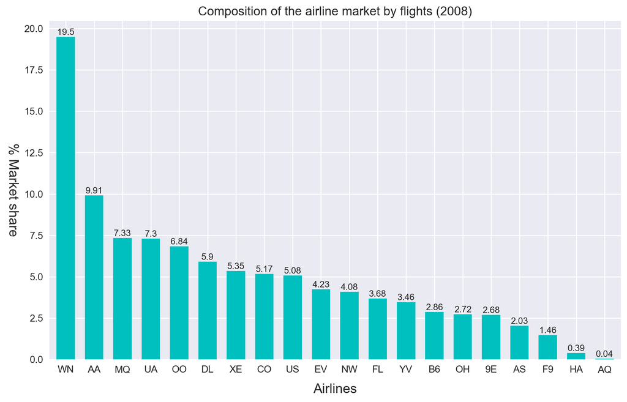

```python
# MARKET SHARE

# Variables
airnames=df['UniqueCarrier'].value_counts().index.tolist()
market = round((df['UniqueCarrier'].value_counts()/df['UniqueCarrier'].value_counts().sum())*100,2)

#PlotStyle
plt.style.use('seaborn')

### Figure
fig = plt.figure(figsize =(11.5, 7))
fig.set_dpi(200)

# Plot
market.plot.bar(fontsize = 11, width=0.65, color = ('c'))

### Customize Plot
plt.title('Composition of the airline market by flights (2008)', fontsize=14)
plt.xlabel('Airlines', fontsize=15, labelpad=10)
plt.ylabel('% Market share', fontsize=15, rotation=-90, labelpad=20)
plt.xticks(rotation=0)
# annotation
for m in range(len(market)):
    plt.annotate(str(market[m]), xy=(m, market[m]), ha='center', va='bottom', size=10);

#fig.savefig('test.png')
```

Podemos observar en el gráfico que la empresa **Southwest (WN)** con diferencia es la aerolínea con mas porcentaje de mercado.

Esto indica que Southwest tiene más vuelos por día que cualquier otra aerolinea estadounidense.

**·** Es cierto que 'WN' tiene una mayor flota de aviones por lo que puede ofrece una mayor cantidad de vuelos a precios mas reducidos que sus competidores: Esto explica la cuota de mercado por vuelos. Aunque, 'WN' tine una cuota de mercado cercana 20%, no implica una mayor facturación que sus competidores mas cercanos. La diferencia de precio de las distintas aerolineas podrían alterar la distribución de la cuota de mercado según facturación.

**·** La dominancia del mercado (por vuelos) se concentra principalmente en las 5 primeras aerolíneas con más cuota. Para entender la profundidad y la dominancia de las 5 primeras aerolínias observamos el cúmulo de las 15 aerolineas restantes: Las últimas **15 aerolineas representan el 49.13% de la cuota de mercado**. Frente al **50.87% de cuota de mercado de las 5 primeras aerolíneas.** Para superar el 50% de la cuota de mercado como mínimo se necesitan las últimas 16 aerolíneas: Las 16 últimas aerolíneas representan el 55.96% de la cuota de mercado.

| Aeorolínea | %Cuota de mercado |
| --- | --- |
| 5 Primeras aerolíneas | 50.87 % |
| 15 Últimas aerolíneas | 49.13 % |
| Total | 100 % |

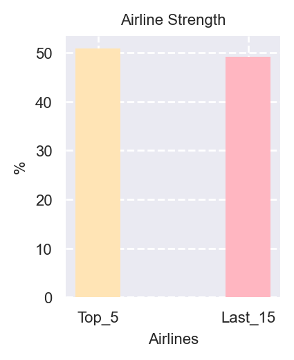

```python
# Market Dominance

# Variables
total=df['UniqueCarrier'].value_counts().sum()
top5 = round(df['UniqueCarrier'].value_counts()[:5].sum()/total*100, 2)
last15 = round(df['UniqueCarrier'].value_counts()[5:].sum()/total*100, 2)

# StylePlot
plt.style.use('seaborn')

# Figure
fig, ax  = plt.subplots(figsize=(2,2.5), dpi=200)

# Plot
ax.bar([1, 2], [top5, last15], width=0.3,
       tick_label=['Top_5', 'Last_15'], align='center', color=('moccasin','lightpink'))

# Customize
ax.set_title('Airline Strength', size=8)
ax.set_xlabel('Airlines', size=8)
ax.set_ylabel('%', size=8)
ax.tick_params(axis='both', which='major', labelsize=8)

# Background: grid, facecolor
ax.grid(b=True, which='both', axis='both', color='w', linestyle='--')
#ax.set_facecolor('grey')

plt.show()
```

### FLIGHTS DELAY

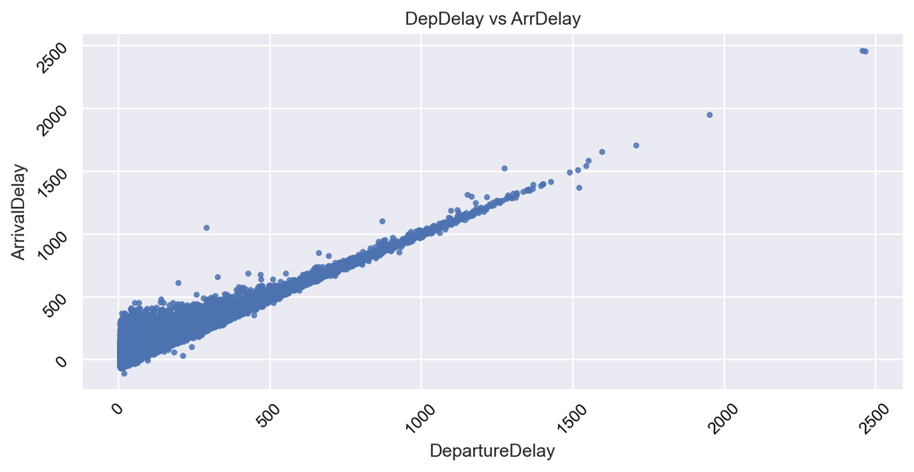

```python
# Gráfico DepDelay vs ArrDelay:

# Variables
depdelay = df['DepDelay'] # retrasos del vuelo
arrdelay = df['ArrDelay']

# StylePlot
plt.style.use('seaborn')

### Figure
fig, axs = plt.subplots(figsize=(9, 4), dpi=200)

# Plot
axs.scatter(depdelay,arrdelay, marker='.', s=45, alpha=.85)

### Customize
axs.grid(b=True)
axs.set_title('DepDelay vs ArrDelay', fontsize = 11)
axs.set_xlabel('DepartureDelay', fontsize = 11)
axs.set_ylabel('ArrivalDelay', fontsize = 11)
axs.tick_params(axis='both',labelsize= 10, rotation=45, labelcolor='k');
```

### DAYS WITH MOST FLIGHTS

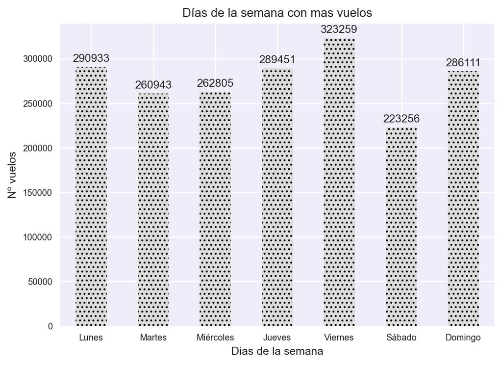

```python
# Dias de la semana con más vuelos:

# Variables
dayweek = df['DayOfWeek'].value_counts().sort_index()
percent = (dayweek/len(df['DayOfWeek']))*100 # Porcentaje de los vuelos por semana
dayweek.index = ['Lunes', 'Martes', 'Miércoles', 'Jueves', 'Viernes', 'Sábado', 'Domingo']

### Figure
fig = plt.figure(figsize =(7, 5), dpi=180)

# Background
ax = fig.add_subplot(111)
ax.patch.set(facecolor='lavender', alpha=.65)

# Plot
plots = dayweek.plot.bar(fontsize = 8, width=0.5, hatch='...', color='gainsboro')

for bar in plots.patches: # anotation
    plots.annotate(format(bar.get_height(), '.0f'),
                   (bar.get_x() + bar.get_width()/2, bar.get_height()),
                   ha='center', va='center', size=10, xytext=(0, 7), textcoords='offset points')

### Customize plot
plt.title('Días de la semana con mas vuelos', loc='center', fontsize=11)
plt.xlabel('Dias de la semana', loc='center', fontsize=10)
plt.ylabel('Nº vuelos', loc='center', fontsize=10)
plt.xticks(rotation=0);
```

1. Viernes, lunes y jueves son los días de la semana con más viajes acumulados. Los viernes se podría explicar por un cúmulo de viajes de negocios/turismo/ocio/familiar. Lunes y jueves principalmente por viajes de negocios.
1. Mientras que sábado, miércoles y martes son los días de la semana con menos tráfico aéreo, ideales para viajar sin mucha movilidad en el aeropuerto.

## Guardar el dataset en un fichero excel

```python
# Save dataset to excel file.

df[:5000].to_excel('delay.xlsx', index=False)
```